# stat140 project2

Van Nguyen

2024-11-15

## Part 1:

```r
library(faraway)
# ?resceram
```

The resceram data set looks at the effect of the resistors’ shape on the noise it make. The noise variable represent the current noise level. shape represent the shape of the resistor. plate represent which plate it was on. We are trying to learn whether the shape and/ or plate affects the noise of the resistor.

## Part 2:

```r
attach(resceram)
xtabs(noise ~ shape + plate)
```

```
##      plate
## shape    1    2    3    4
##     A 1.11 1.70 1.60 0.00
##     B 0.00 1.22 1.11 1.22
##     C 0.95 0.00 1.52 1.54
##     D 0.82 0.97 0.00 1.18
```

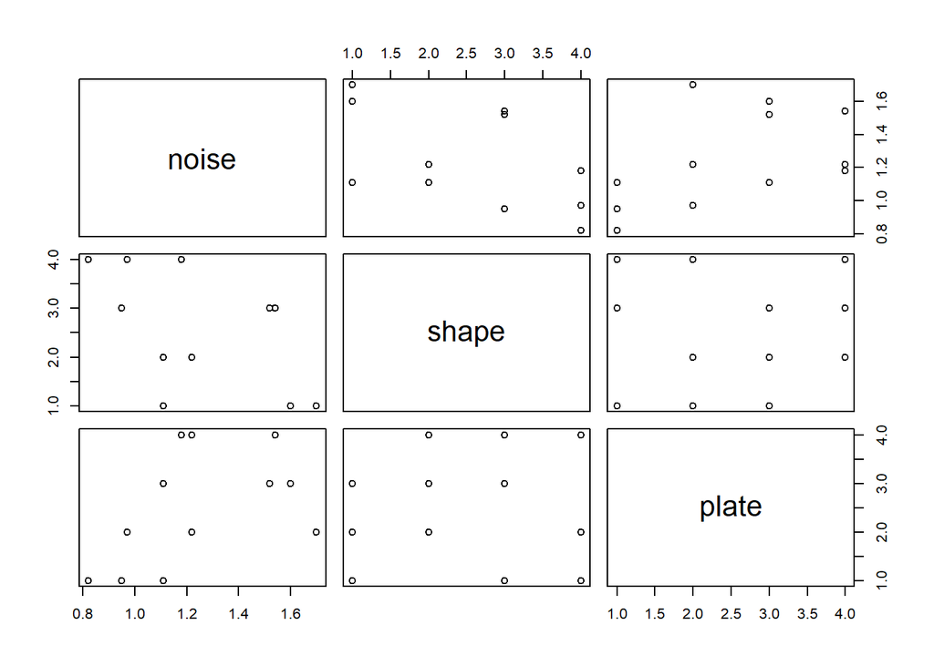

```r
pairs(resceram)
```

```r
summary(resceram)
```

```
##      noise       shape plate
##  Min.   :0.820   A:3   1:3
##  1st Qu.:1.075   B:3   2:3
##  Median :1.200   C:3   3:3
##  Mean   :1.245   D:3   4:3
##  3rd Qu.:1.525
##  Max.   :1.700
```

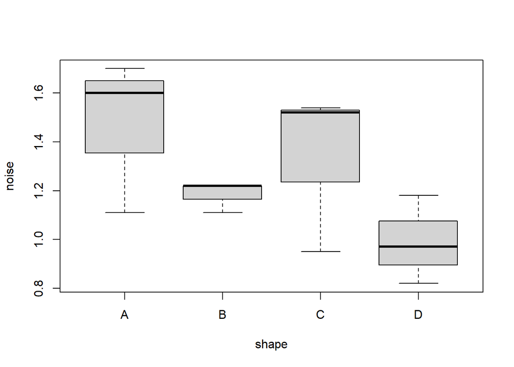

```r
plot(noise ~ shape) # Inital looks suggests shape D and B to be the most significant
```

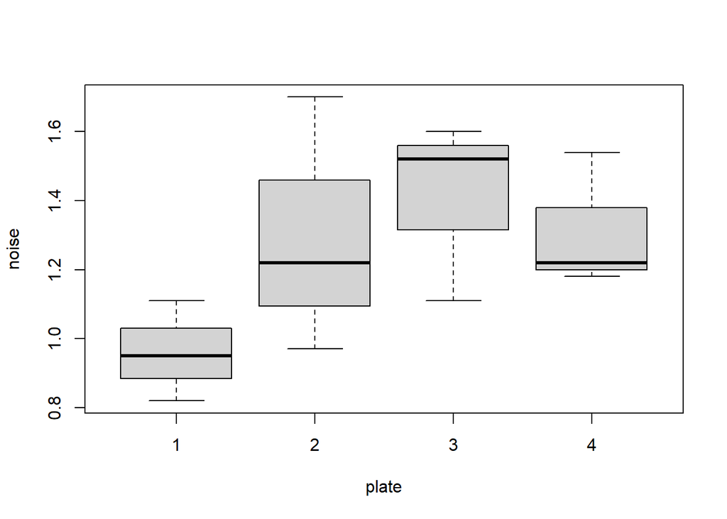

```r
plot(noise ~ plate) # Inital looks suggests plate 1 to be the most significant
```

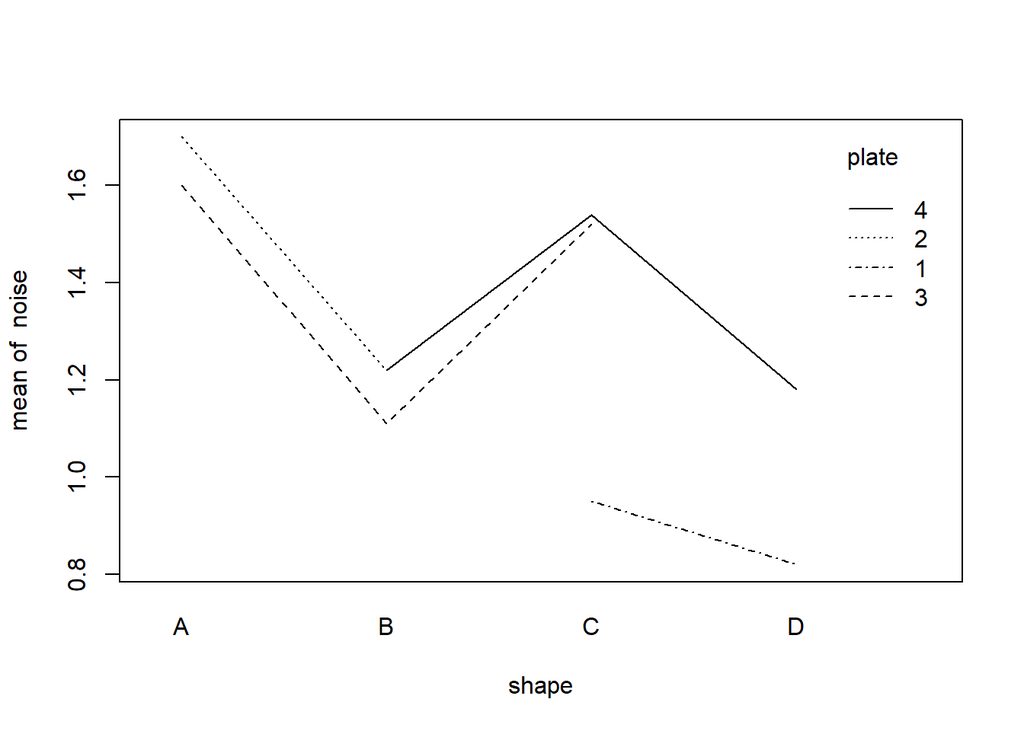

```r
interaction.plot(shape,plate,noise) # Doesn't look like there is interaction
```

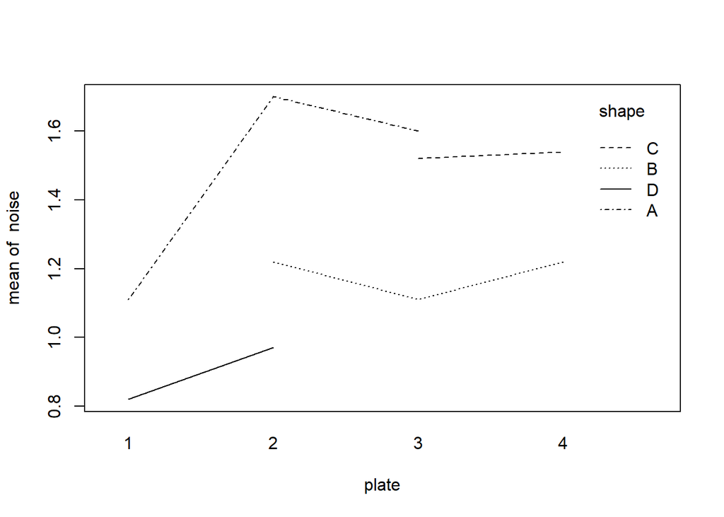

```r
interaction.plot(plate,shape,noise)
```

## Part 3:

Since there is two other variables beside noise, there can be only one treatment and one block, meaning it does not follow a Latin square design.

Using plate as the block, there are 4 blocks ($b=4$) and each has a block size of 3 ($k=3$). There is 4 shape ($t=4$). Each shape appear 3 times ($r=3$). Since,
$$b = t > k\\
b*k = t*r =12\\
\lambda = \frac{bk(k-1)}{t(t-1)} = \frac{24}{12} = 2 \in \mathbb{Z}\\
\lambda(t-1) = r(k-1) = 6$$

the resceram data set follows a balance incomplete block design (BIB).

```r
mod1 <- lm(noise ~ plate + shape)

anova(mod1) # Tells us that the plate and shape are statistically significant
```

```
## Analysis of Variance Table
##
## Response: noise
##           Df  Sum Sq  Mean Sq F value  Pr(>F)
## plate      3 0.34737 0.115789  8.4548 0.02105 *
## shape      3 0.46506 0.155019 11.3194 0.01146 *
## Residuals  5 0.06847 0.013695
## ---
## Signif. codes:  0 '***' 0.001 '**' 0.01 '*' 0.05 '.' 0.1 ' ' 1
```

```r
summary(mod1)
```

```
##
## Call:
## lm(formula = noise ~ plate + shape)
##
## Residuals:
##        1        2        3        4        5        6        7        8
## -0.07000 -0.07375  0.14375  0.08375  0.05875 -0.14250 -0.01375 -0.04875
##        9       10       11       12
##  0.06250 -0.01000  0.01125 -0.00125
##
## Coefficients:
##             Estimate Std. Error t value Pr(>|t|)
## (Intercept)  1.18000    0.08938  13.202 4.45e-05 ***
## plate2       0.43625    0.10135   4.305  0.00768 **
## plate3       0.43375    0.10135   4.280  0.00786 **
## plate4       0.50500    0.10135   4.983  0.00417 **
## shapeB      -0.45500    0.10135  -4.490  0.00646 **
## shapeC      -0.15625    0.10135  -1.542  0.18378
## shapeD      -0.50375    0.10135  -4.971  0.00421 **
## ---
## Signif. codes:  0 '***' 0.001 '**' 0.01 '*' 0.05 '.' 0.1 ' ' 1
##
## Residual standard error: 0.117 on 5 degrees of freedom
## Multiple R-squared:  0.9223, Adjusted R-squared:  0.829
## F-statistic: 9.887 on 6 and 5 DF,  p-value: 0.01184
```

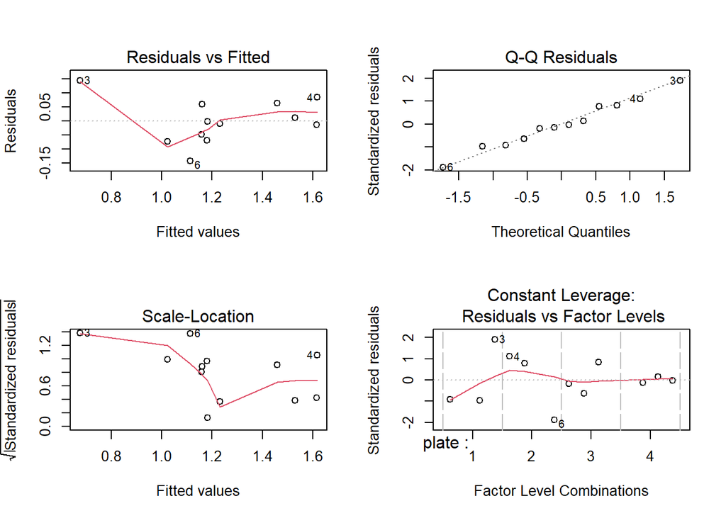

```r
par(mfrow=c(2,2))
plot(mod1) # Everything looks fine, no fanning in the Residuals vs Fitted and the Q-Q looks almost perfectly linear. I only notice that row 3 and 4 are constant outliers in the graphs but it does not look to affect things much to be an issue.
```

```r
coef(summary(mod1))[5:7,] # std. error 0.10134718
```

```
##        Estimate Std. Error   t value    Pr(>|t|)
## shapeB -0.45500  0.1013472 -4.489518 0.006461675
## shapeC -0.15625  0.1013472 -1.541730 0.183776895
## shapeD -0.50375  0.1013472 -4.970538 0.004209813
```

```r
tcoefs <- c(0, coef(mod1)[5:7])
abs(outer(tcoefs, tcoefs,"-")) > qtukey(0.95, 4, 5)*0.10134718/sqrt(2)
```

```
##              shapeB shapeC shapeD
##        FALSE   TRUE  FALSE   TRUE
## shapeB  TRUE  FALSE  FALSE  FALSE
## shapeC FALSE  FALSE  FALSE  FALSE
## shapeD  TRUE  FALSE  FALSE  FALSE
```

```r
# The difference between A-B and A-D are significantly different.

mod2 <- lm(noise ~ shape)
(summary(mod2)$sig / summary(mod1)$sig)^2 # 454% more effeicent!
```

```
## [1] 4.53937
```